# The Plan to Dismantle DEI

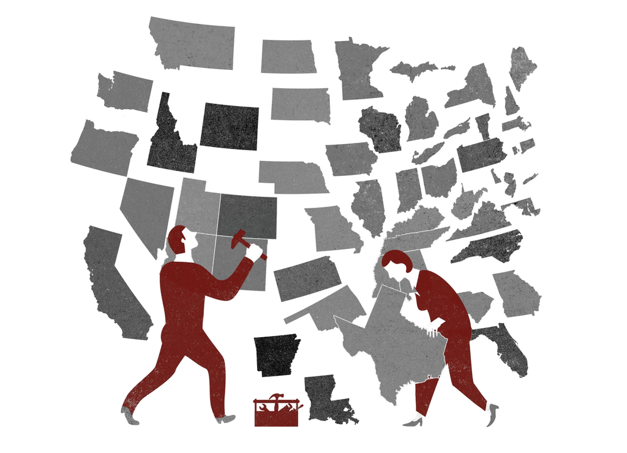

# The Plan to Dismantle DEI

## Conservatives take on colleges’ “illiberal” bureaucracy.

André da Loba for The Chronicle

By [Eric Kelderman](https://www.chronicle.com/author/eric-kelderman)

Two influential conservative think tanks described in detail on Wednesday how legislatures could dismantle the administrative structures that support diversity, equity, and inclusion efforts at public colleges.

[Model state legislation](https://www.manhattan-institute.org/model-dei-legislation), written by scholars at the Manhattan and Goldwater Institutes, if passed, would prohibit colleges from hiring diversity, equity, and inclusion officers; bar trainings that instruct staff to identify and fight against systemic racism; eliminate requirements for employees to commit to diversity statements; and could disallow even institutional commitments to social justice and recommendations that students be addressed by their preferred pronouns.

“This package is meant to reverse illiberal tendencies that have swept across higher education in the past decade,” said Ilya Shapiro, one of the authors of the model bill and a senior fellow and director of constitutional studies at the Manhattan Institute.

It’s the means of the DEI efforts that are more of a problem than the goals of making campuses more diverse and inclusive, Shapiro wrote in an email. “Should colleges afford equal opportunity? Reach out to underprivileged communities to make sure otherwise qualified students aren’t being overlooked? Make students feel welcome and supported on campus? Of course — all of these are no-brainers,” he wrote.

But institutions should pursue those outcomes, he added, in a way that doesn’t “determine and enforce hierarchies of privilege, compel speech, or extend preferential treatment based on race, gender, sexual orientation, etc.”

> DEI officers form a kind of revolutionary vanguard on campuses; their livelihood can only be justified by discovering — i.e., manufacturing — new inequities to be remedied.

In explaining the rationale for the document, Shapiro and his co-authors decry DEI offices as Soviet-style enforcers of left-wing ideology that are wasting tuition money and public tax dollars.

“There is a widespread consensus among conservative academics and higher education experts, as well as many centrist faculty, that university DEI offices are the nerve center of woke ideology on university campuses,” the authors write. “DEI officers form a kind of revolutionary vanguard on campuses; their livelihood can only be justified by discovering — i.e., manufacturing — new inequities to be remedied.”

In addition to prohibiting such administrative units, the proposed legislation would make public colleges that violate its codes subject to lawsuits by individual students, alumni, or faculty. The draft also recommends that money spent on diversity programs be redirected to scholarships for low- and middle-income students at the discretion of a governing board.

The model bill, as written, could have a variety of unintended consequences, said Jeremy C. Young, senior manager for free expression and education at the nonprofit advocacy group PEN America, including diminished efforts to recruit underserved populations as students and faculty members. The bill could also violate free-speech rights by constraining administrators and faculty from even advocating for diversity, equity, and inclusion, and could cause institutions to violate accreditation standards, Young said.

“There’s no way in which it is helpful to have state governments come in and pass something like this,” Young said.

Several colleges in recent years have deployed a litany of efforts to better serve students of color, who today make up the majority of high-school graduates. Colleges have hired DEI officers, reckoned with the ways their institutions in the past banned students of color, and set aside money, programs, and spaces on campus to serve the needs of such students.

The Black Lives Matter movement has created even more momentum. DEI offices are now ubiquitous on the campuses of public and private nonprofit colleges. In addition, improving the outcomes of Black, Hispanic, and Native American students, which often lag behind those of white and Asian students, is [one of the top priorities](https://sheeo.org/wp-content/uploads/2023/01/Policy-Issue-Survey.pdf) of state higher-education leaders, according to a recent survey from the State Higher Education Executive Officers Association.

But as those efforts have grown, conservative activists and elected officials have pushed back, arguing that such measures may discriminate against white students and violate academic freedom, and that they are part of a liberal effort to indoctrinate students.

Over the past two years, state lawmakers in 15 Republican-controlled states have passed 19 bills that seek to restrict teaching on issues of race, racism, and gender, [according to figures from PEN America](https://pen.org/report/educational-gag-orders/). Laws in seven states specifically address instruction on those topics at public colleges.

Many of those laws are likely to face legal challenges. In November, a [state court judge](https://www.chronicle.com/article/conjuring-orwell-florida-judge-blasts-dystopian-ban-on-woke-instruction) in Florida suspended parts of the so-called Stop WOKE Act championed by Gov. Ron DeSantis, who has made it a mission to snuff out diversity, equity, and inclusion proposals at public colleges.

There are also efforts afoot by college leaders to root out color-conscious programs from their campuses. On Wednesday, the Florida College System released a statement, attributed to the presidents of its member institutions, that they would [identify and eliminate](https://www.chronicle.com/article/floridas-state-colleges-say-theyll-stop-promoting-critical-race-theory) any academic requirement or program “that compels belief in critical race theory or related concepts such as intersectionality.”

“We must ensure that our institutions of higher learning are focused on academic excellence and the pursuit of truth, not the imposition of trendy ideology,” DeSantis [said during his inaugural speech](https://www.flgov.com/2023/01/03/governor-desantis-delivers-inaugural-address-sets-priorities-for-second-term/) for a second term. A possible presidential contender in 2024, DeSantis [has also asked](https://www.chronicle.com/article/fla-governor-asked-all-public-universities-for-spending-data-on-diversity-and-critical-race-theory) all the state’s public colleges and universities to [provide details](https://www.chronicle.com/article/a-florida-university-is-quickly-assembling-a-list-of-courses-on-diversity-why-desantis-asked) on spending for diversity, equity, and inclusion programs. A [*Chronicle* analysis](https://www.chronicle.com/article/desantis-asked-florida-universities-to-detail-their-diversity-spending-heres-how-they-answered) found that among the state’s public universities, none spent more than 1 percent of their budget on such measures.

The governor has also [appointed a bevy of well-known conservatives](https://www.chronicle.com/article/after-condemning-trendy-ideology-in-higher-ed-floridas-governor-targets-a-small-college) to the Board of Trustees of New College, the state’s public liberal-arts institution. One of those appointees is Christopher F. Rufo, a senior fellow at the Manhattan Institute and director of the initiative on critical race theory, who has pledged to remake the college into a haven for conservative thought and instruction.

Rufo is also among the authors of the model legislation to ban DEI offices at public colleges.

“Left-wing radicals have spent the past fifty years on a ‘long march through the institutions,’” Rufo [tweeted](https://twitter.com/realchrisrufo/status/1611427674483986432?s=20&t=u_bffS6BaDTBAX3AfsoPJw) following his appointment. “We are going to reverse that process, starting now.”

Shapiro, another author of the bill, said [his own experience](https://www.chronicle.com/article/georgetown-reinstated-him-after-a-controversial-tweet-he-quit-anyway) of being investigated by the Office of Institutional Diversity, Equity, and Affirmative Action at Georgetown University informed his thinking on the model bill. Last year he was named executive director of the Center for the Constitution at Georgetown’s law school. Before he began his duties, his job was put on hold after he criticized the nomination of Ketanji Brown Jackson to the U.S. Supreme Court in a way that some, including the dean of the law school, considered “appalling.” After a four-month inquiry, Georgetown reinstated Shapiro, but he resigned immediately.